# MBA-ESG-MBDCDO-Data-Mining-R-Markdown-Cours-02-et-03-2018-11-12

Antoine GNIMASSOUN, Nicolas ROBIN

23/01/2019

Ce script R reproduit les étapes vues avec le logiciel SPAD de Coheris Analytics destiné au Data Mining et à l’analyse prédictive.

Sont reproduites les 3 étapes principales suivantes :

- **Étape 1 : le calcul des statistiques descriptives.**
- **Étape 2 : le groupement des modalités intéressantes.**
- **Étape 3 : la régression logistique.**

## Avant-propos

Avant de procéder à l’exécution des 3 étapes, il est nécessaire de charger :

- les bibliothèques R nécessaires au projet
- les données globales
- la table **base_credit** sur laquelle vont s’appuyer les 3 étapes.

```r
# Chargement des bibliotheques R necessaires au projet.
# Assurez-vous que les bibliotheques suivantes ont bien ete installees dans RStudio.
library(xlsx)
library(dplyr)
library(stats)
library(tidyr)
library(DT)
library(glm2)

# Definition de l'espace de travail.
Espace_De_Travail_Antoine <- 'C:/Users/antoi/Desktop/MBA/Mes cours/Data Mining'
Espace_De_Travail_Nicolas <- '/Users/nrobin/Documents/GitHub/projet_datamining_1'

# CHOISIR VOTRE ESPACE DE TRAVAIL ICI, SI VOUS DESIREZ EXECUTER CE SCRIPT AVEC RSTUDIO.
Espace_De_Travail_Antoine_Eric <- 'C:/Users/TBD...'

# CHOISIR VOTRE ESPACE DE TRAVAIL ICI, SI VOUS DESIREZ EXECUTER CE SCRIPT AVEC RSTUDIO.
Espace_De_Travail_Choisi <- Espace_De_Travail_Nicolas

# Le nom du fichier de donnees a telecharger
Fichier_de_donnees <- "base_credit_mac.xlsx"

# Mise en place de l'espace de travail de l'environnement pour l'execution des scripts R.
setwd(Espace_De_Travail_Choisi)

# Chargement du fichier de donnees dans une table nommee base_credit.
base_credit <- read.xlsx(Fichier_de_donnees, sheetIndex=1, header=TRUE, stringsAsFactors=TRUE, encoding="UTF-8")

#base_credit <- fread(paste0(Espace_De_Travail_Choisi, "/", Fichier_de_donnees), sep="|", header = TRUE, dec = ",", stringsAsFactors = FALSE)

#base_credit <- as.data.frame(base_credit)
```

## Etape 1 - Statistiques descriptives

Nous avons crée une fonction qui renvoie les statistiques descriptives initiales sur les variables continues de la base_credit.

**Description** : Cette fonction retourne the statistiques descriptives (en tant que dataframe)

**Paramètre en entrée** : colonne, une colonne renfermant un ensemble de variables continues.

**Valeur retournée** : un dataframe renfermant les statistiques de base équivalentes à celles rendues dans SPAD. Elle contient :

- Variable : le nom de la varible.
- Effectif, Moyenne, Ecart type, Minimum, Maximum, Min2, Max2 et CV et Médiane.

```r
stats_descri_personnalise <- function(varname, x) {

  # Definition du nombre de virgules apres la virgule.
  # Valeur choisie a 3 comme dans SPAD.
  precision = 3

  # Fonction qui renvoie un dataframe avec l'ensemble des statistiques descriptives des valeurs de la table.
  data_frame_stats <- data.frame (
    Variable=varname,
    # Calcul du nombre de lignes, sans donnees manquantes
    Effectif=length(x[!is.na(x)]),
    # Calcul de la moyenne
    Moyenne=round(mean(x, na.rm=TRUE),precision),
    # Calcul de l'ecart-type
    'Ecart Type'=round(sd(x, na.rm=TRUE),precision),
    # Minimum
    Minimum=min(x,na.rm = TRUE),
    # Maximum
    Maximum=max(x,na.rm = TRUE),
    # Min2
    'Min 2'=sort(unique(x,na.rm = TRUE))[2],
    # Max2
    'Max 2'=sort(unique(x,na.rm = TRUE),decreasing = TRUE)[2],
    # Calcul du Coefficiant de Variation
    'CV'=round(sd(x, na.rm=TRUE) / mean(x, na.rm=TRUE), precision),
    # Calcul de la mediane
    Mediane=median(x, na.rm=TRUE)
    # Et en plus...
    # Calcul de la variance
    #Variance=round(var(x, na.rm=TRUE), precision),
    # Nombre de donnees manquantes
    #'Valeurs manquantes'=length(x[is.na(x)]),
    # Pourcentage de valeurs manquantes
    #'Taux de valeurs manquantes'=length(x[is.na(x)])
  )

  return(data_frame_stats)
}

# --------------------------------------------------------------------------------------------------
# Pour obtenir les statistiques descriptives des variables continues, appeler la fonction
# stats_descri_personnalise() et lui preciser la colonne des variables continues dont on veut les statistiques.
table_column_names <- colnames(base_credit)
score1_column_index = 14
score2_column_index = 15

stat_score1 <- stats_descri_personnalise(table_column_names[score1_column_index], base_credit$Score.1)
stat_score2 <- stats_descri_personnalise(table_column_names[score2_column_index], base_credit$Score.2)
stat_score <- rbind.data.frame(stat_score1, stat_score2)

# Affichage des statistiques dans un widget HTML
datatable(stat_score,
          rownames = FALSE,
          options = list(paging = FALSE, searching = FALSE, info = FALSE, scrollX = 400))
```

| Variable | Effectif | Moyenne | Ecart.Type | Minimum | Maximum | Min.2 | Max.2 | CV | Mediane |
| --- | --- | --- | --- | --- | --- | --- | --- | --- | --- |
| Score.1 | 468 | 554.177 | 185.933 | 110 | 945 | 115 | 925 | 0.336 | 570 |
| Score.2 | 468 | 513.408 | 169.463 | 50 | 960 | 70 | 945 | 0.33 | 500 |

## Étape 2 - Regroupement des modalités

Dans cette étape, on commence par décrire les variables qualitatives que l’on a choisi de regrouper :

- Situation Familiale
- Domiciliation de l’épargne

On récupère et affiche les effectifs et les fréquences de chacune des variables.

**Situation familiale :**

```r
# 1 - Situation familiale
# 1a - Calcul des effectifs
effectifs1=table(base_credit$Situation.familiale,useNA = "always")
# 1b - Calcul des frequences
frequences1=round(prop.table(effectifs1),3)
# 1c - Creation d'une table avec effectifs et calculs
effectifs_et_frequences_situation_familliale <- cbind(effectifs1, frequences1)

# Affichage du calcul des effectifs et des frequences de la situation familiale.
datatable(effectifs_et_frequences_situation_familliale,
          rownames = TRUE,
          options = list(paging = FALSE, searching = FALSE, info = FALSE))
```

|  | effectifs1 | frequences1 |
| --- | --- | --- |
| célibataire | 170 | 0.363 |
| divorcé | 61 | 0.13 |
| marié | 221 | 0.472 |
| veuf | 16 | 0.034 |
|  | 0 | 0 |

**Domiciliation de l’épargne :**

```r
# 2 - Domiciliation de l'epargne
# 2a - Calcul des effectifs
effectifs2=table(base_credit$Domiciliation.de.l.épargne,useNA = "always")
# 2b - Calcul des frequences
frequences2=round(prop.table(effectifs2),3)
# 2c - Creation d'une table avec effectifs et calculs
effectifs_et_frequences_domiciliation_epargne <- cbind(effectifs2, frequences2)

# Affichage du calcul des effectifs et des frequences de la domiciliation de l'epargne.
datatable(effectifs_et_frequences_domiciliation_epargne,
          rownames = TRUE,
          options = list(paging = FALSE, searching = FALSE, info = FALSE))
```

|  | effectifs2 | frequences2 |
| --- | --- | --- |
| de 10 à 100K épargne | 32 | 0.068 |
| moins de 10K épargne | 58 | 0.124 |
| pas d'épargne | 370 | 0.791 |
| plus de 100K épargne | 8 | 0.017 |
|  | 0 | 0 |

Puis on procède au **regroupement des modalités** :

- “divorcé” + “veuf” –> **divorcé/veuf**
- “de 10 à 100K épargne” + “plus de 100K épargne” –> **plus de 10K épargne**

On modifie la table “base_credit” de manière à prendre en compte ce regroupement.

```r
# Regroupement de modalités "divorce" et "veuf" sur la variable situation_familiale
base_credit$Situation.familiale<-recode(base_credit$Situation.familiale,
                                        "célibataire" = "célibataire",
                                        "divorcé" = "divorcé/veuf",
                                        "marié" = "marié",
                                        "veuf" = "divorcé/veuf")

# Regroupement de modalites "de 10 a 100K epargne" et "plus de 100K epargne" sur
# la variable domiciliation_de_lepargne
base_credit$Domiciliation.de.l.épargne<-recode(base_credit$Domiciliation.de.l.épargne,
                                                "moins de 10K épargne"="moins de 10K épargne",
                                                "pas d'épargne"="pas d'épargne",
                                                "de 10 à 100K épargne"="plus de 10K épargne",
                                                "plus de 100K épargne"="plus de 10K épargne")

# DESCRIPTION DES VARIABLES QUALITATIVES REGROUPEES
# 1 - Situation familiale
# 1a - Calcul des effectifs
effectifs_modifiees1=table(base_credit$Situation.familiale,useNA = "always")
# 1b - Calcul des frequences
frequences_modifiees1=round(prop.table(effectifs_modifiees1),3)
# 1c - Creation d'une table avec effectifs et calculs
affectifs_et_frequences_situation_familliale_modifiee <- cbind(effectifs_modifiees1, frequences_modifiees1)

# Affichage du calcul des effectifs et des frequences de la situation familiale.
datatable(affectifs_et_frequences_situation_familliale_modifiee,
          rownames = TRUE,
          options = list(paging = FALSE, searching = FALSE, info = FALSE))
```

|  | effectifs_modifiees1 | frequences_modifiees1 |
| --- | --- | --- |
| célibataire | 170 | 0.363 |
| divorcé/veuf | 77 | 0.165 |
| marié | 221 | 0.472 |
|  | 0 | 0 |

```r
# 2 - Domiciliation de l'epargne
# 2a - Calcul des effectifs
effectifs_modifiee2=table(base_credit$Domiciliation.de.l.épargne,useNA = "always")
# 2b - Calcul des frequences
frequences_modifiees2=round(prop.table(effectifs_modifiee2),3)
# 2c - Creation d'une table avec effectifs et calculs
affectifs_et_frequences_domiciliation_epargne_modifiee <- cbind(effectifs_modifiee2, frequences_modifiees2)

# Affichage du calcul des effectifs et des frequences de la domiciliation de l'épargne.
datatable(affectifs_et_frequences_domiciliation_epargne_modifiee,
          rownames = TRUE,
          options = list(paging = FALSE, searching = FALSE, info = FALSE))
```

|  | effectifs_modifiee2 | frequences_modifiees2 |
| --- | --- | --- |
| plus de 10K épargne | 40 | 0.085 |
| moins de 10K épargne | 58 | 0.124 |
| pas d'épargne | 370 | 0.791 |
|  | 0 | 0 |

## Étape 3 - Régression logistique

### 3.1 Choix de la variable explicative

La variable à expliquer sélectionnée est : **Type de Client**

Dans la table **base_client**, on discrétise cette variable en changeant la valeur **bon client** à la valeur 1, et la valeur **mauvais client** à la valeur 0.

```r
# Discretisation de la variable a expliquer
base_credit$Type.de.client<- recode(base_credit$Type.de.client,
                                    "Bon client"= 1,
                                    "Mauvais client"= 0)
```

### 3.2 Création des échantillons de test et d’apprentissage

On crée nos echantillons de test et d’apprentissage avec les valeurs 1 et 2.  
L’**apprentissage** se fait sur **75% de la population** et la **validation** sur **25% de la population**.

```r
# On cree nos echantillons de test et d'apprentissage avec les valeurs 1 et 2
ind <- sample(2, nrow(base_credit), replace=T, prob=c(0.75,0.25))

# Training sur 75% de la population
tdata<- base_credit[ind==1,]

# Validation sur 25% de la population
vdata<- base_credit[ind==2,]
```

### 3.3 Choix des modalités de référence

```r
# Choix des modalites de reference
base_credit$Age.du.client <- relevel(base_credit$Age.du.client, ref = "moins de 23 ans")
base_credit$Situation.familiale <- relevel(base_credit$Situation.familiale, ref = "divorcé/veuf")
base_credit$Ancienneté <- relevel(base_credit$Ancienneté, ref = "anc. 1 an ou moins")
base_credit$Domiciliation.du.salaire <- relevel(base_credit$Domiciliation.du.salaire, ref = "Non domicilié")
base_credit$Domiciliation.de.l.épargne <- relevel(base_credit$Domiciliation.de.l.épargne, ref = "pas d'épargne")
base_credit$Profession <- relevel(base_credit$Profession, ref = "cadre")
base_credit$Moyenne.encours <- relevel(base_credit$Moyenne.encours, ref = "plus de 5 K encours")
base_credit$Moyenne.des.mouvements <- relevel(base_credit$Moyenne.des.mouvements, ref = "de 10 à 30K mouvt")
base_credit$Cumul.des.débits <- relevel(base_credit$Cumul.des.débits, ref = "plus de 100 débits")
base_credit$Autorisation.de.découvert <- relevel(base_credit$Autorisation.de.découvert, ref = "découvert autorisé")
base_credit$Interdiction.de.chéquier <- relevel(base_credit$Interdiction.de.chéquier, ref = "chéquier interdit")
```

### 3.4 Estimation du modèle avec les donnees d’entrainement

On prend comme variable explicative, la variable **Type.de.Client** (index 2 dans le code)

Les autres variables sont considérées comme étant des variables explicatives (index 3 a 13 dans le code). La première variable n’est pas prise en compte, car il s’agit de l’**Identifiant.Client**.

On utilise la fonction *glm()* pour utiliser le **modèle lineaire généralisé** pour faire la **régression logistique**.

```r
# Estimation du modele avec les donnees d'entrainement
# On prend comme variable explicative, la variable "Type.de.Client" (index 2)
# Les autres variables sont considerees comme etant des variables explicatives (index 3 a 13).
# La premiere variable n'est pas prise en compte car il s'agit de l'"Identifiant.Client".
# On utilise la fonction glm() pour utiliser le modele lineaire generalise pour faire la regression logistique.
fit.glm = glm(tdata[,2]~.,data=tdata[,3:13],family=binomial)
```

On calcule et affiche les résultats de la régression avec les variables.

```r
# On affiche les resultats de la regression avec les variables
drop1(fit.glm,test ="F")
```

```
## Single term deletions
##
## Model:
## tdata[, 2] ~ Age.du.client + Situation.familiale + Ancienneté +
##     Domiciliation.du.salaire + Domiciliation.de.l.épargne +
##     Profession + Moyenne.encours + Moyenne.des.mouvements + Cumul.des.débits +
##     Autorisation.de.découvert + Interdiction.de.chéquier
##                            Df Deviance    AIC F value    Pr(>F)
## <none>                          309.59 361.59
## Age.du.client               3   316.59 362.59  2.5851 0.0531107 .
## Situation.familiale         2   318.08 366.08  4.7022 0.0096681 **
## Ancienneté                  5   330.85 372.85  4.7107 0.0003561 ***
## Domiciliation.du.salaire    1   335.64 385.64 28.8560 1.442e-07 ***
## Domiciliation.de.l.épargne  2   310.14 358.14  0.3059 0.7366749
## Profession                  2   310.71 358.71  0.6209 0.5380664
## Moyenne.encours             2   312.56 360.56  1.6450 0.1945276
## Moyenne.des.mouvements      3   313.71 359.71  1.5216 0.2086307
## Cumul.des.débits            2   328.90 376.90 10.6979 3.112e-05 ***
## Autorisation.de.découvert   1   313.00 363.00  3.7749 0.0528451 .
## Interdiction.de.chéquier    2   330.99 378.99 11.8547 1.051e-05 ***
## ---
## Signif. codes:  0 '***' 0.001 '**' 0.01 '*' 0.05 '.' 0.1 ' ' 1
```

On calcule et affiche un résumé des coefficients utilisés pour la regression, c’est à dire que l’on affiche les modalites pour chaque variable.

```r
# Affiche un resume des coefficients utilises pour la regression.
# On affiche les modalites pour chaque variable.
summary(fit.glm)
```

```
##
## Call:
## glm(formula = tdata[, 2] ~ ., family = binomial, data = tdata[,
##     3:13])
##
## Deviance Residuals:
##      Min        1Q    Median        3Q       Max
## -2.20156  -0.65734  -0.00004   0.64705   2.64347
##
## Coefficients:
##                                                Estimate Std. Error z value
## (Intercept)                                     14.5885   820.4748   0.018
## Age.du.clientde 40 à 50 ans                      0.4456     0.3832   1.163
## Age.du.clientmoins de 23 ans                    -0.8211     0.4668  -1.759
## Age.du.clientplus de 50 ans                      0.3360     0.4582   0.733
## Situation.familialedivorcé/veuf                 -1.3325     0.4797  -2.778
## Situation.familialemarié                        -0.6775     0.3592  -1.886
## Anciennetéanc. de 1 à 4 ans                      0.6655     0.5130   1.297
## Anciennetéanc. de 4 à 6 ans                      1.7511     0.4867   3.598
## Anciennetéanc. de 6 à 12 ans                     0.9338     0.4958   1.884
## Anciennetéanc. plus  12 ans                      1.4678     0.6293   2.332
## Anciennetéanc. plus 12 ans                       1.9750     0.6330   3.120
## Domiciliation.du.salaireOui domicilié            1.6002     0.3265   4.902
## Domiciliation.de.l.épargnemoins de 10K épargne  -0.1186     0.8603  -0.138
## Domiciliation.de.l.épargnepas d'épargne         -0.5224     1.0377  -0.503
## Professioncadre                                  0.5347     0.5075   1.054
## Professionemployé                                0.1658     0.3316   0.500
## Moyenne.encoursmoins de 2K encours              -0.6028     0.4926  -1.224
## Moyenne.encoursplus de 5 K encours               0.8495     0.8324   1.020
## Moyenne.des.mouvementsde 30 à 50K mouvt          0.2880     0.4573   0.630
## Moyenne.des.mouvementsmoins 10 K mouvt          -0.4583     0.4517  -1.014
## Moyenne.des.mouvementsplus de 50K mouvt          0.3073     0.5079   0.605
## Cumul.des.débitsmoins de 40 débits               1.1012     0.3666   3.004
## Cumul.des.débitsplus de 100 débits              -0.9405     0.4485  -2.097
## Autorisation.de.découvertdécouvert interdit    -15.4761   820.4738  -0.019
## Interdiction.de.chéquierchéquier autorisé      -16.0186   820.4738  -0.020
## Interdiction.de.chéquierchéquier interdit      -17.4266   820.4736  -0.021
##                                                Pr(>|z|)
## (Intercept)                                    0.985814
## Age.du.clientde 40 à 50 ans                    0.244878
```

[output cut: 19 more lines]

```
## Cumul.des.débitsmoins de 40 débits             0.002662 **
## Cumul.des.débitsplus de 100 débits             0.035970 *
## Autorisation.de.découvertdécouvert interdit    0.984951
## Interdiction.de.chéquierchéquier autorisé      0.984423
## Interdiction.de.chéquierchéquier interdit      0.983054
## ---
## Signif. codes:  0 '***' 0.001 '**' 0.01 '*' 0.05 '.' 0.1 ' ' 1
##
## (Dispersion parameter for binomial family taken to be 1)
##
##     Null deviance: 511.52  on 368  degrees of freedom
## Residual deviance: 309.59  on 343  degrees of freedom
## AIC: 361.59
##
## Number of Fisher Scoring iterations: 16
```

### 3.5 Données de test et d’entrainement

On procède maintenent à l’étape de **prédiction**, d’abord avec les **données de test** :

```r
# Prediction avec les donnees de test
score.glm = predict(fit.glm, vdata[,3:13],type="response")
sum(as.numeric(predict.glm(fit.glm,vdata[,3:13],type="response")>=0.5))
```

```
## [1] 51
```

```r
class.glm=as.numeric(predict.glm(fit.glm,vdata[,3:13],type="response")>=0.5)
table(class.glm,vdata[,2])
```

```
##
## class.glm  0  1
##         0 37 11
##         1  8 43
```

Ensuite avec les **données d’entraînement** :

```r
# Prediction avec les donnees d'entrainement.
score.glm2 = predict(fit.glm, tdata[,3:13],type="response")
sum(as.numeric(predict.glm(fit.glm,tdata[,3:13],type="response")>=0.5))
```

```
## [1] 184
```

```r
class.glm2=as.numeric(predict.glm(fit.glm,tdata[,3:13],type="response")>=0.5)
table(class.glm2,tdata[,2])
```

```
##
## class.glm2   0   1
##          0 150  35
##          1  36 148
```

### 3.6 Calcul des proportions pour la matrice de confusion

Pour le calcul des proportions, nous avons choisi une **valeur de seuil à 0.5, soit 50%**.

Proportion de **bien classés (bon clients)** sur les **données de test** :

```r
# ---------------------------------------------------------------------------------------------------
# Calcul des proportions pour la matrice de confusion (on a choisi comme seuil 0.5)
# ---------------------------------------------------------------------------------------------------
# Proportion de bien classes (bon clients) sur les donnees de test
sum( score.glm >= 0.5 & vdata[,2]==1)/sum(vdata[,2]==1)
```

```
## [1] 0.7962963
```

Proportion de **bien classés (mauvais clients)** sur les **données de test** :

```r
# Proportion de bien classes (mauvais clients) sur les donnees de test
sum( score.glm < 0.5 & vdata[,2]==0)/sum(vdata[,2]==0)
```

```
## [1] 0.8222222
```

Proportion de **bien classés (bon clients)** sur les **données d’entrainement** :

```r
# Proportion de bien classes (bon clients) sur les donnees d'entrainement
sum( score.glm2 >= 0.5 & tdata[,2]==1)/sum(tdata[,2]==1)
```

```
## [1] 0.8087432
```

Proportion de **bien classés (mauvais clients)** sur les données d’entrainement** :

```r
# Proportion de bien classes (mauvais clients) sur les donnees d'entrainement
sum( score.glm2 < 0.5 & tdata[,2]==0)/sum(tdata[,2]==0)
```

```
## [1] 0.8064516
```

### 3.7 Affichage de la courbe de gain et de la courbe de ROC.

La courbe de ROC avait été traitée lors du premier envoi. C’est pourquoi nous l’avons laissée dans le présent document. Nous expliquerons cette courbe dans le prochain livrable de ce R-Markdown, livrable qui devra aussi inclure la courbe de gain. Si vous êtes d’accord, pouvez-vous nous faire déjà un retour sur cette courbe de manière à pouvoir y apporter des informations qui vous apparaissent comme étant manquantes ?

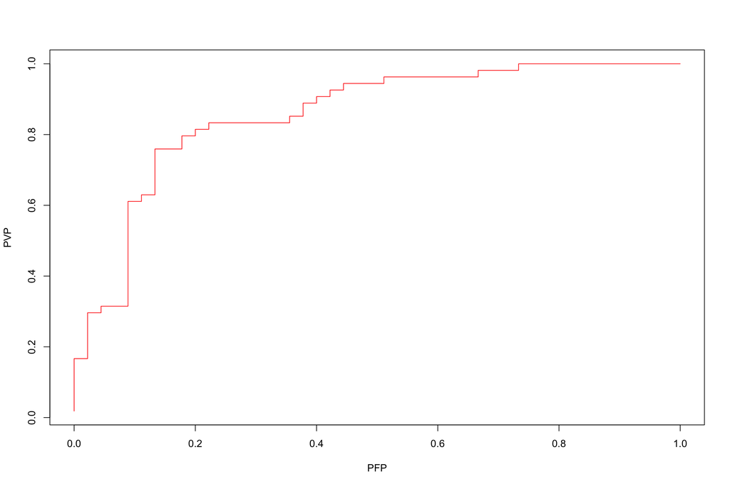

```r
# Graduation des axes pour la representation de la courbe ROC
s=quantile(score.glm,probs=seq(0,1,0.01))
# Vecteur vide qui comportera par la suite tous les pourcentages de vrais positifs (PVP)
PVP = rep(0,length(s))
# Vecteur vide qui comportera par la suite tous les pourcentages de faux positifs (PFP)
PFP = rep(0,length(s))

# Pour chaque valeur du vecteur s (vu comme seuil), on calcule les PVP et PFP
for (i in 1:length(s)){
  PVP[i]=sum(score.glm>=s[i]& vdata[,2]==1)/sum(vdata[,2]==1)
  PFP[i]=sum( score.glm >=s[i] & vdata[,2]==0)/sum(vdata[,2]==0) }

# Affichage de la courbe ROC montrant les clients positifs classes positifs
# versus les clients positifs classes negatifs.
plot(PFP,PVP,type="l",col="red")
```